# Week9

**NOTE:** Most code is written in Python 3 with the packages `numpy`, `sympy`, and `matplotlib` installed.

### 13.5.3

The definition is

$$v_{\ell}^{(k)} = c\sin\left(\frac{k\ell\pi}{m+1}\right)$$

where $c=\sqrt{\frac{2}{m+1}}$ is constant.

**Case 1:** $j\ne k$

$$\sum_{\ell=1}^m v_\ell^{(k)}v_\ell^{(j)} = c^2 \sum_{\ell=1}^m\sin\left(\frac{k\ell\pi}{m+1}\right)\sin\left(\frac{j\ell\pi}{m+1}\right)$$

Notice that $$\sin\left(\frac{k\ell}{m+1}\right)\sin\left(\frac{j\ell}{m+1}\right)= \frac12\left[\cos\left(\frac{(k-j)\ell}{m+1}\right)-\cos\left(\frac{(k+j)\ell}{m+1}\right)\right]$$

and

$$2\sin(a)\sum_{\ell=1}^m \cos(2a\ell) = \sum_{\ell=1}^m\sin(2a\ell+a)-\sin(2a\ell -a) = \sin((2m+1)a)-\sin(a)$$

Therefore (taking $a=\frac{(k\pm j)\pi}{2m+2}$),

$$\sum_{\ell=1}^m \cos\left(\frac{(k\pm j)\ell\pi}{m+1}\right) = \frac{\sin\left(\frac{(2m+1)(k\pm j)\pi}{2m+2}\right)}{2\sin\left(\frac{(k\pm j)\pi}{2m+2}\right)}-\frac12$$

Now, if $k\pm j$ is even ($k+j\equiv k-j\pmod{2}$) then

$$\sin\left(\frac{(2m+1)(k\pm j)\pi}{2m+2}\right) = -\sin\left(\frac{(k\pm j)\pi}{2m+2}\right)$$

and it all reduces to $-1$. If $k\pm j$ is odd then

$$\sin\left(\frac{(2m+1)(k\pm j)\pi}{2m+2}\right) = \sin\left(\frac{(k\pm j)\pi}{2m+2}\right)$$

and it reduces to $0$.

Then

$$\sum_{\ell=1}^m \cos\left(\frac{(k - j)\ell\pi}{m+1}\right) - \sum_{\ell=1}^m \cos\left(\frac{(k + j)\ell\pi}{m+1}\right) = 0,$$

and

$$\sum_{\ell=1}^m v_\ell^{(k)}v_\ell^{(j)} = \frac{c^2}{2}\cdot 0 = 0$$

**Case 2:** $j=k$

The reason the above proof breaks when $j=k$ is because $\sin(a) = 0$ when $a=\frac{(k-j)\pi}{m+1}$ so we cannot divide by it.

Anyway, if $j=k$ then $j+k$ is even and so (from the above)

$$\sum_{l=1}^m \cos\left(\frac{(k + j)\ell\pi}{m+1}\right) = -1.$$

Also,

$$\sum_{l=1}^m \cos\left(\frac{(k - j)\ell\pi}{m+1}\right) = m\cos(0) = m$$

Then

$$\sum_{\ell=1}^m v_\ell^{(k)}v_\ell^{(j)} = \frac{c^2}{2}\cdot (m+1) = 1.$$

Then the vectors $\textbf{v}^{(k)}$ form an orthonormal basis.

### 13.5.5

**(a)** Notice that if $u$ satisfies the given equation it also satisfies

$$\int_{0}^1 \phi_j\frac{d}{dx}\left((1+x^2)\frac{du}{dx}\right) dx = \int_{0}^1 f\phi_j dx$$$$\Longleftrightarrow$$$$-\int_0^1\phi_j'(1+x^2)u'dx = \int_0^1 f\phi_j dx$$

because $$\left.\phi_j(x)(1+x^2)u'(x)\right|_{0}^1 = 0.$$

Now let

$$\hat{u}\sum_{i=1}^{n-1}c_i\phi_i$$

be an approximate solution to $u$. We want it to satisfy the equations

$$-\int_0^1\phi_j'(1+x^2)\hat{u}'dx = \int_{h(j-1)}^{h(j+1)} f\phi_j dx$$$$\Longleftrightarrow$$$$-\sum_{i=1}^{n-1}\int_0^1\phi_j'(1+x^2)c_i\phi_i'dx = \int_0^1f\phi_j dx$$

which is equivalent to

$$A\textbf{c} = \textbf{f}$$

where $$f_j = -\int_0^1f\phi_j dx$$ and $$a_{ij}=\int_0^1\phi_j'(1+x^2)c_i\phi_i'dx$$

Now, if $|i-j| > 1$, one of $\phi'_i, \phi'_j$ is equal to $0$ for any $x$, so $a_{ij}=0$.

If $i=j$ then we have

$$a_{ii} = \int_{h(i-1)}^{h(i+1)}\frac{1+x^2}{h^2}dx = \frac2h + h\left(2i^2+\frac23\right).$$

If $|i-j|=1$ and $\text{min}(i, j)=k,$ then

$$a_{ij} = -\int_{hk}^{h(k+1)}\frac{1+x^2}{h}dx = -\frac{1}{h}-h\left(k^2+k+\frac13\right).$$

**(b)** Code follows below:

```
Error:
```

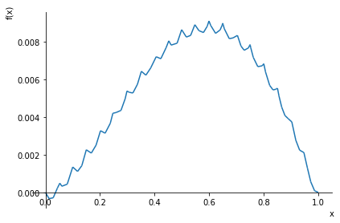

```
Gobal error:
0.009105166694484801
```

```python
import numpy as np
import sympy as sp
from sympy.abc import x
import matplotlib.pyplot as plt

f = -2*(3*x**2 - x + 1)

n = 20
h=1/n

phi = []
phi_lefts = [1-i+x/h for i in range(1, n)]
phi_rights = [-x/h+1+i for i in range(1, n)]
for i in range(1, n):
    phi.append(sp.Piecewise(
        (0, x<h*(i-1)),
        (0, x>h*(i+1)),
        (phi_lefts[i-1], x <= h*i),
        (phi_rights[i-1], x <= h*(i+1))
    ))

A = [[0 for i in range(n-1)] for j in range(n-1)]
for i in range(n-1):
    A[i][i] = 2*n + h*(2*i**2 + 2/3)
    if i < n-2:
        A[i][i+1] = -n - h*(i**2+i+1/3)
        A[i+1][i] = -n - h*(i**2+i+1/3)

A = sp.Matrix(A)
fs = []
for i in range(n-1):
    # quicker to break it into left/right parts when integrating
    v = sp.integrate(f*phi_lefts[i], (x, h*(i), h*(i+1)))+sp.integrate(f*phi_rights[i], (x, h*(i+1), h*(i+2)))
    fs.append(v)

A_inv = np.array(A.inv()).astype(np.float64)
g = np.array(fs).astype(np.float64)

c = -A_inv @ g

u_hat = sum(c[i]*phi[i] for i in range(n-1))
u =  x*(1-x)

error = sp.lambdify(x, abs(u_hat-u))

print("Error:")
sp.plot(u_hat-u, (x, 0, 1))

print("Gobal error:")
print(max(error(np.linspace(0, 1, n*n))))
```

### 13.5.6

**(a)** We have $$\frac{d^2\phi_j(x)}{dx^2} = -j^2\pi^2\phi_j$$

And so we want $$-\sum_{j=1}^3c_jj^2\pi^2\phi_j = \sum_{j=1}^3c_j\phi_j + x^2$$ to be true for $x=1/4, 2/4, 3/4$. Rearranging we have

$$\sum_{j=1}^3(1+j^2\pi^2)c_j\phi_j(x)=-x^2$$

Taking $x=1/4, 2/4, 3/4$ we get the three equations

$$\frac{c_1(1+\pi^2)}{\sqrt2} + c_2(1+4\pi^2) - \frac{c_3(1+9\pi^2)}{\sqrt2} = -\frac{1}{16}$$$$c_1(1+\pi^2) - c_3(1+9\pi^2) = -\frac{1}{4}$$$$-\frac{c_1(1+\pi^2)}{\sqrt2} - c_2(1+4\pi^2) + \frac{c_3(1+9\pi^2)}{\sqrt2} = -\frac{9}{16}$$

The first and third equations are negatives of each other (for the LHS), but $$-\left(-\frac{1}{16}\right)\ne -\frac{9}{16}$$ so there's no solution!

**(b)** This time

$$\phi''_1(x) = -2,\quad \phi''_2(x) = 2-6x,\quad \phi''_3(x) = 6-12x$$

and so plugging in $x=1/4, 2/4, 3/4$ we get the equations

$$-\frac{35}{16}c_1 + \frac{29}{64}c_2 + \frac{765}{256}c_3 = \frac1{16}$$$$-\frac94c_1 -\frac98 c_2 -\frac1{16}c_3 = \frac14$$$$-\frac{35}{16}c_1 -\frac{169}{64}c_2 -\frac{795}{256}c_3 = \frac9{16}$$

which does have a solution.

```python
# Calculate the coefficients for (b)...

from fractions import Fraction

phipps = [lambda x: -2, lambda x: 2-6*x, lambda x: 6-12*x]
phis = [lambda x: x*(1-x), lambda x: x**2*(1-x), lambda x: x**3*(1-x)]

for x in [Fraction(1, 4), Fraction(2, 4), Fraction(3, 4)]:
    c = []
    for j in range(3):
        c.append(phipps[j](x) - phis[j](x))
    print(*c, x**2)
```

```
-35/16 29/64 765/256 1/16
-9/4 -9/8 -1/16 1/4
-35/16 -169/64 -795/256 9/16
```

**(c)** Code is actually written in MATLAB this time, and attached separately.

It uses a degree $12$ polynomial with the $13$ Chebyschev points $$p_i = \frac12+\frac12\cos\left(\frac{i\pi}{N}\right).$$

It's global error is $3.4574\cdot 10^{-13}$ which is good to about machine precision.

### 4.

**(a)**

We have $$u''(i)\approx \frac{u(i+h) - 2u(i) + u(i-h)}{h^2}$$ and $$u'(i)\approx \frac{u(i+h)-u(i)}{h}$$

So we have

$$\frac{u_{i+1}-2u_{i}+u_{i-1}}{h^2} + \frac{u_{i+1}-u_{i}}{h} + bu_i = 1$$

for $0 < i < n$, and the boundary conditions

$$\frac{u_1-u_0}{h} = 2$$$$\frac{u_n-u_{n-1}}{h} = -3.$$

Solving these equations gives the approximate solution. Code follows:

[output not shown]

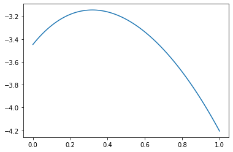

```python
def solve(n):
    h = 1/n

    A = []
    b = []

    # Left point:
    row = np.zeros(n+1)
    row[1] = n; row[0] = -n
    A.append(row); b.append(2)

    # Right point:
    row = np.zeros(n+1)
    row[-1] = n; row[-2] = -n
    A.append(row); b.append(-3)

    # Middle points:
    for i in range(1, n):
        row = np.zeros(n+1)
        row[i-1] = n**2
        row[i] = -2*n**2 - n + b_value
        row[i+1] = n**2 + n
        A.append(row); b.append(1)

    A = np.array(A)
    u = np.linalg.inv(A) @ b
    return u

b_value = -2

n = 100
u = solve(n)
print("For h=1/10,")
print(f"u(0.5) = {u[n//2]}")
plt.plot(np.linspace(0, 1, n+1), u)
```

**(b)** Rahter than using $h=1/10^j$ I am using $h=1/2^j$ because `numpy`'s default matrix inverse function is too slow for big matrices and I don't want to write a custom function to use the tridiagonal special sauce.

Code follows:

```
Slope = 2.0646416022684995
```

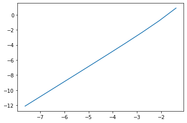

```python
e = np.e
def u(x):
    return -(2+3*e**2)*np.exp(x)/(e**3-1) - (3*e**2+2*e**3)*np.exp(-2*x)/(2*(e**3-1)) - 1/2

norms = []
hs = []

for j in range(2, 12):
    n = 2**j
    hs.append(1/2**j)
    u_hat = solve(n)
    u_true = u(np.linspace(0, 1, n+1))
    norms.append(max((u_hat-u_true)**2))

plt.plot(np.log(hs), np.log(norms))
slope, b = np.polyfit(np.log(hs), np.log(norms), 1)
print("Slope =",slope)
```

**(c)** The determinant is always $0$. This is because the sum of the values in any row is equal to $0$, and so the columns are not linearly independent.

```python
b_value = 0
def get_det(n):
    h = 1/n

    A = []
    b = []

    # Left point:
    row = np.zeros(n+1)
    row[1] = n; row[0] = -n
    A.append(row); b.append(2)

    # Right point:
    row = np.zeros(n+1)
    row[-1] = n; row[-2] = -n
    A.append(row); b.append(-3)

    # Middle points:
    for i in range(1, n):
        row = np.zeros(n+1)
        row[i-1] = n**2
        row[i] = -2*n**2 - n + b_value
        row[i+1] = n**2 + n
        A.append(row); b.append(1)

    A = np.array(A)
    print(A)
    return np.linalg.det(A)

get_det(7)
```

```
[[  -7.    7.    0.    0.    0.    0.    0.    0.]
 [   0.    0.    0.    0.    0.    0.   -7.    7.]
 [  49. -105.   56.    0.    0.    0.    0.    0.]
 [   0.   49. -105.   56.    0.    0.    0.    0.]
 [   0.    0.   49. -105.   56.    0.    0.    0.]
 [   0.    0.    0.   49. -105.   56.    0.    0.]
 [   0.    0.    0.    0.   49. -105.   56.    0.]
 [   0.    0.    0.    0.    0.   49. -105.   56.]]
```

```
0.0
```

### 5

**(a)** We have $$u''(i)\approx \frac{u(i+h) - 2u(i) + u(i-h)}{h^2}$$

so

$$\frac{u_{i+1}-2u_{i}+u_{i-1}}{h^2} + au_i = 1$$

for $0 < i < n$. There are also the boundary conditions

$$u_0 = 1, u_n = -1.$$

Solving these equations gives the approximate solution. Code follows:

```
For h=pi/100,
u(pi/2) = 1.3252932339837897
```

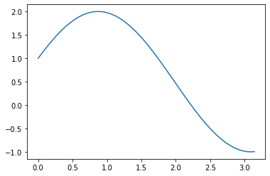

```python
def solve(n):
    h = 1/n

    A = []
    b = []

    # Left point:
    row = np.zeros(n+1)
    row[0] = 1;
    A.append(row); b.append(1)

    # Right point:
    row = np.zeros(n+1)
    row[-1] = 1;
    A.append(row); b.append(-1)

    # Middle points:
    for i in range(1, n):
        row = np.zeros(n+1)
        row[i-1] = n**2/np.pi**2
        row[i] = -2*n**2/np.pi**2 + a_value
        row[i+1] = n**2/np.pi**2
        A.append(row); b.append(1)

    A = np.array(A)
    u = np.linalg.inv(A) @ b
    return u

a_value = 2

n = 100
u = solve(n)
print("For h=pi/100,")
print(f"u(pi/2) = {u[n//2]}")
plt.plot(np.linspace(0, np.pi, n+1), u)
```

**(b)** It is absolutely not correct. The determinant is super large, and so the matrix is very ill-conditioned. In fact, there is no solution for this particular BVP. A basis for the homogenous equation is $\{\sin(x), \cos(x)\}$ and so $u$ is of the form $$1+c_1\sin x + c_2\cos x$$ but no values of $c_1, c_2$ fit the boundary conditions.

Code follows:

```
For h=pi/100,
u(pi/2) = 15480.017585900321
det(A) = -1.5083965156280976e+295
```

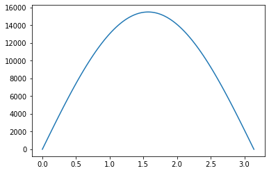

```python
def get_det(n):
    h = 1/n

    A = []
    b = []

    # Left point:
    row = np.zeros(n+1)
    row[0] = 1;
    A.append(row); b.append(1)

    # Right point:
    row = np.zeros(n+1)
    row[-1] = 1;
    A.append(row); b.append(-1)

    # Middle points:
    for i in range(1, n):
        row = np.zeros(n+1)
        row[i-1] = n**2/np.pi**2
        row[i] = -2*n**2/np.pi**2 + a_value
        row[i+1] = n**2/np.pi**2
        A.append(row); b.append(1)

    A = np.array(A)
    return np.linalg.det(A)

a_value = 1

n = 100
u = solve(n)
print("For h=pi/100,")
print(f"u(pi/2) = {u[n//2]}")
print(f"det(A) = {get_det(n)}")
plt.plot(np.linspace(0, np.pi, n+1), u)
```